# BRECI

Peter D. Wilson

9 January 2021

# Binned Relative Environmental Change Index (BRECI)

## Background

Ecological niche models (ENMs) are now widely used in conservation and assessment tasks, and in population genetic and evolutionary ecology studies. Alternate terms for these models include Environmental Niche Models, Species Distribution Models (SDMs) and Habitat Suitability Models (HSMs).

A frequent aspect using this class of model is to contrast the nature of suitable environmental conditions at two times (e.g. climate change impacts), or in two locations (e.g. potential impact of invasive species). The outputs from these models are typically raster maps of suitability scores. There are many avenues to compare and contrast the differences between two model output maps but they are often statistical scores which makes it challenging to fully appreciate the nature of differences between times or regions. Single statistical scores also make it difficult to understand the implications difference may have for management decisions, or their influences on population genetic or evolutionary processes.

The purpose of BRECI is to provide a simple but informative graphical representation of differences between two raster maps. This vignette is to demonstrate the use of the functions *BRECIplot()* and *gainLossMaps*, to produce effective graphics to assist in the interpretation of differences between two raster maps.

## Basic requirements

To use *BRECIplot()* the two rasters to be compared *must*:

- be loadable into the *R* environment as *rasterLayer* objects from the *R*-package *raster*;
- have the same raster geometry (e.g. same spatial extent and origin, same grid cell size or resolution); and,
- have suitability scores scaled in the same way (e.g. 0 (no suitability) to 1 (maximum suitability)).

## Types of change

A fundamental question in contrasts between ENM rasters is: Is there a *gain* or *loss* of suitability?

In many examples in the ENM literature this question is answered by making binary maps using a threshold suitability value and measuring the difference in area between the two rasters. There are a a number of methods available to chose a threshold value but a fundamental problem is that, by making a continuously varying suitability scale into a binary one, we loose useful information. For example, we cannot tell if there is a gain or loss of moderately suitable habitat. This could be an important element in determining, for example, an appropriate conservation management response. A BRECI plot provides a compromise solution to this dilemma by showing relative gain or loss across a user-selected set of score ranges (bins).

## Example BRECIplots

Six simple *rasterLayer* objects are available in the *BRECI* package and we will use them to illustrate the basic use of the functions *BRECIplot()* and *gainLossMaps()*.

### Little change:

Maps *ras1* and *ras2* are an example of two rasters which have only minor differences across all bins.

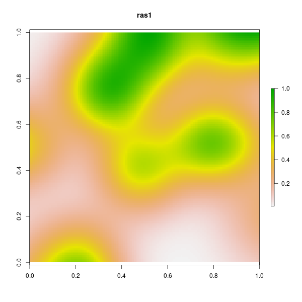

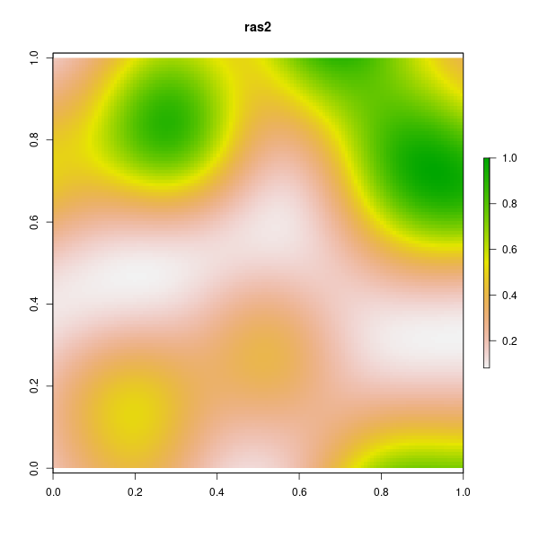

Here is the basic BRECI plot for these two maps:

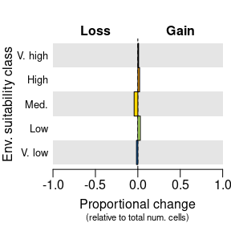

```r
BRECIplot(ras1, ras2, saveToFile = FALSE)
```

Although there is little change in the *overall* gain/loss in each bin or class, looking at the plots for the two rasters shows that there have been major spatial shifts in the distribution of suitability values. This is a useful insight which could help form more appropriate management responses. We will see later how the function *gainLossMaps()* can help us understand and document the nature of these spatial changes.

### Big gains in suitability:

These two rasters are an example of a major gain in suitability.

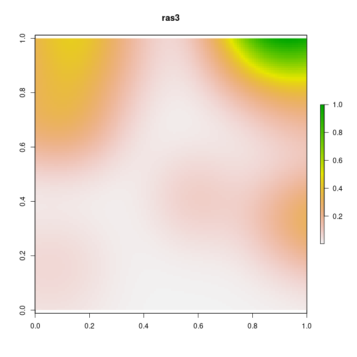

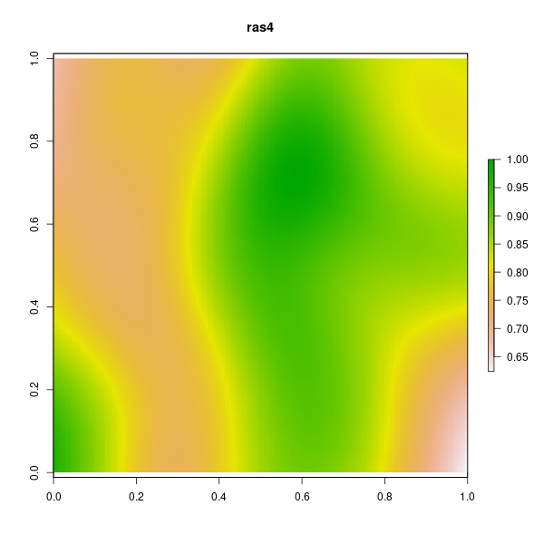

The BRECI plot confirms this but helps us understand that the rise in “Very high” and “High” suitability classes has come about by cells transitioning mostly from “Very low” suitability.

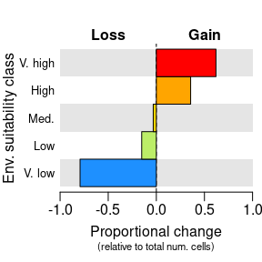

```r
BRECIplot(ras3, ras4, saveToFile = FALSE)
```

### Big losses in suitability:

In this pair of maps, there has been a substantial loss of high suitability areas. The BRECI plot suggests that losses have been fairly widespread within the “Medium” to “Very high” suitability classes.

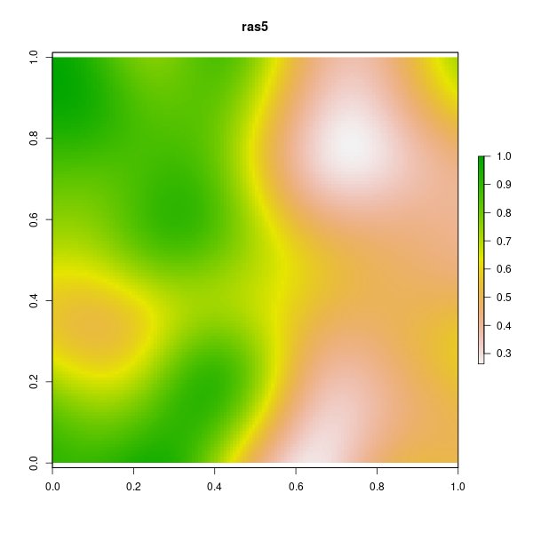

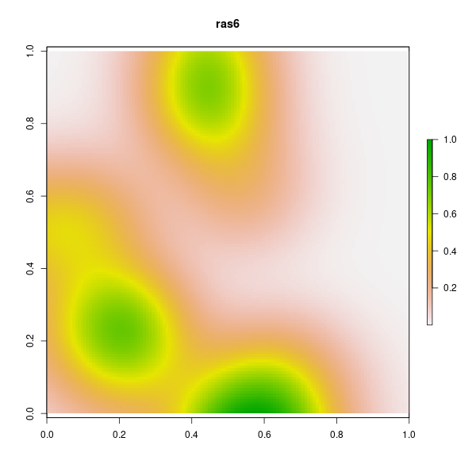

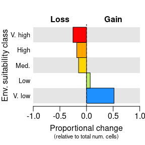

```r
BRECIplot(ras5, ras6, saveToFile = FALSE)
```

### Gain/loss maps:

A BRECI plot shows an overall trend in suitability scores between two raster. It is ‘aspatial’: it does not show *where* on the map transitions have occurred. That could be very important information. It is quiet obvious in our very small and simple examples where spatial changes have occurred, but it becomes a real challenge to make those assessments with out assistance using real-life ENM outputs. The function *gainLossMaps* can provide the needed spatial insights.

To generate the full suite of gain-loss plots we would use the following call:

```r
gainLossMaps(ras1, ras2)
```

Default settings for *saveToRaster* and *saveImages* are FALSE, so images are rendered to the standard graphics device. This allows users to review the plots before deciding on saving GIS-compatible raster files or png images. The function *gainLossMaps()* produces an overall view of areas of gains and losses (as separate overall gain and overall loss maps). It also produces a set of gain or loss pairwise transition maps for each transition.

$k = \sum_{i = 1}^{N - 1} N - i$

where *N* is the number of classes or bins.

The demonstrate how to use the gain-loss plots, we will look at a selection of outputs from the full set of plots produced by the function call:

```r
gainLossMaps(ras1, ras2, outFolder = "/path/to/output_folder", saveImages = TRUE)
```

First, the overall plot of losses:

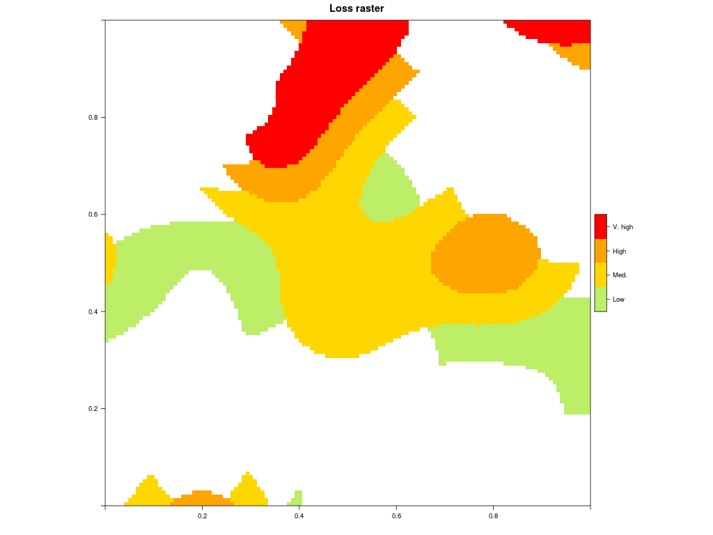

The loss map shows areas of the map in each class or bin which transitioned to a lower bin. For example, the “Very high” area represents cells coded as “Very high” on the first map which transitioned in the second map to one of the lower classes e.g. Very High to Medium, Very high to Low, and so on.

This is useful information for managers and decision-makers, but might also be helpful to know which areas have experienced the greatest shifts; that is, those areas most threatened with change. This information is provided by the set of transition maps which break down changes into unique *from-to* class transitions. For example, here is a transition map for “Very high” to “Medium”:

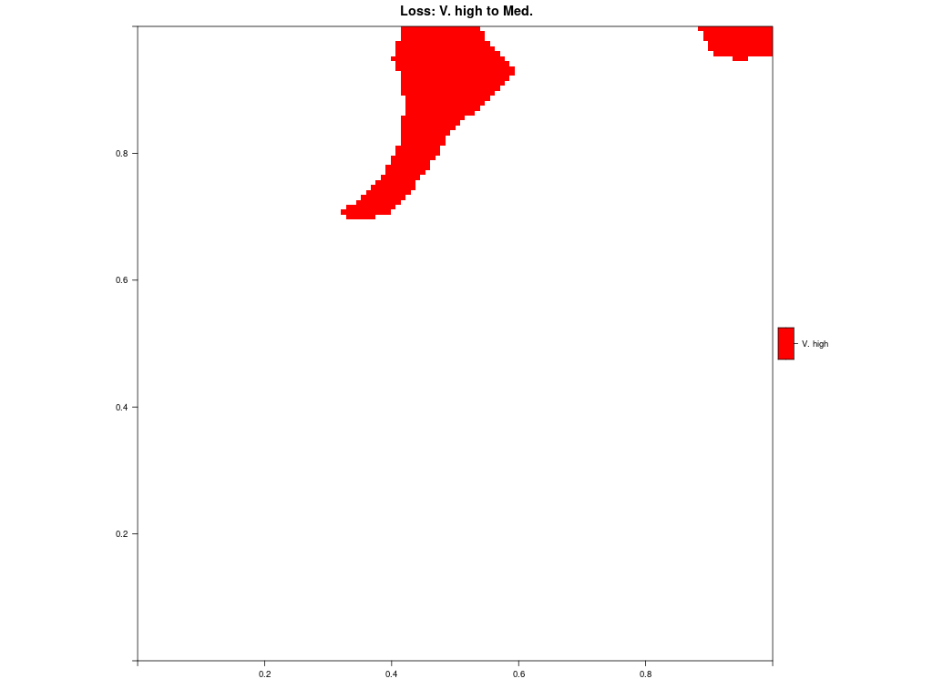

In this map, the colour-coding shows the state of cells in first raster; that is, the class cells transitioned *from* since we are showing losses.

Gains are treated in similar way. Here is the overall gain map:

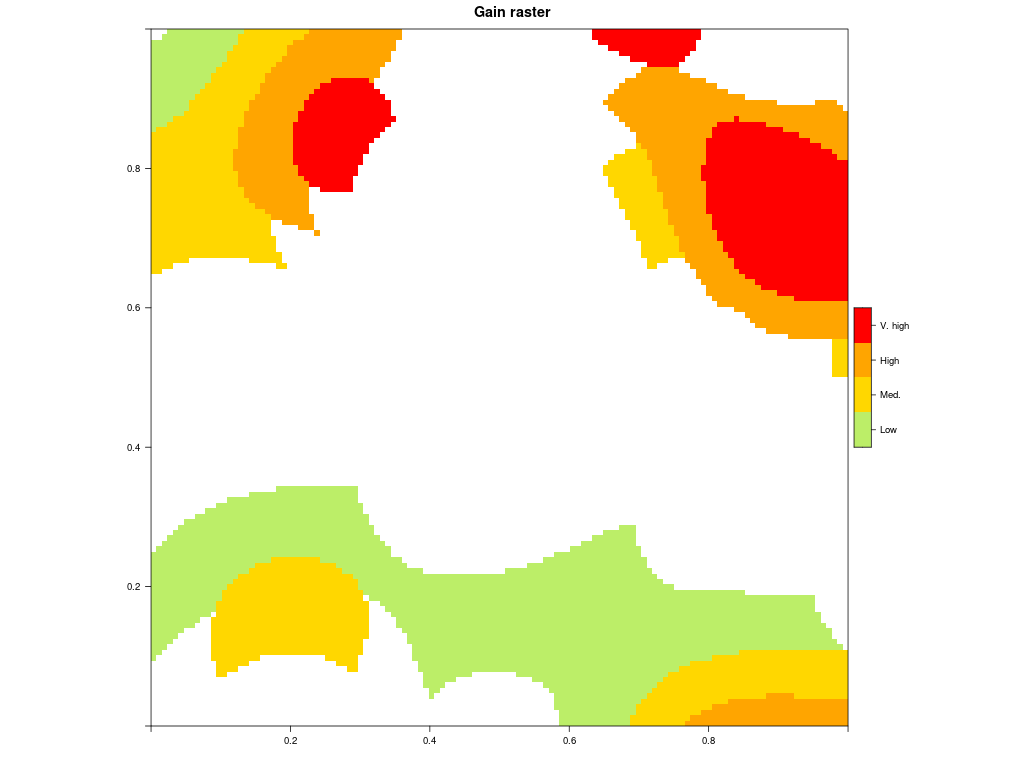

The colour-coding in this case shows the class that a cell transitioned *to* in the second map. And, as with the loss maps we can look at individual transitions to gain a deeper of understanding of the changes. As an example, here is a plot showing cells which transitioned from “Low” in the first map to “Medium” in the second map.

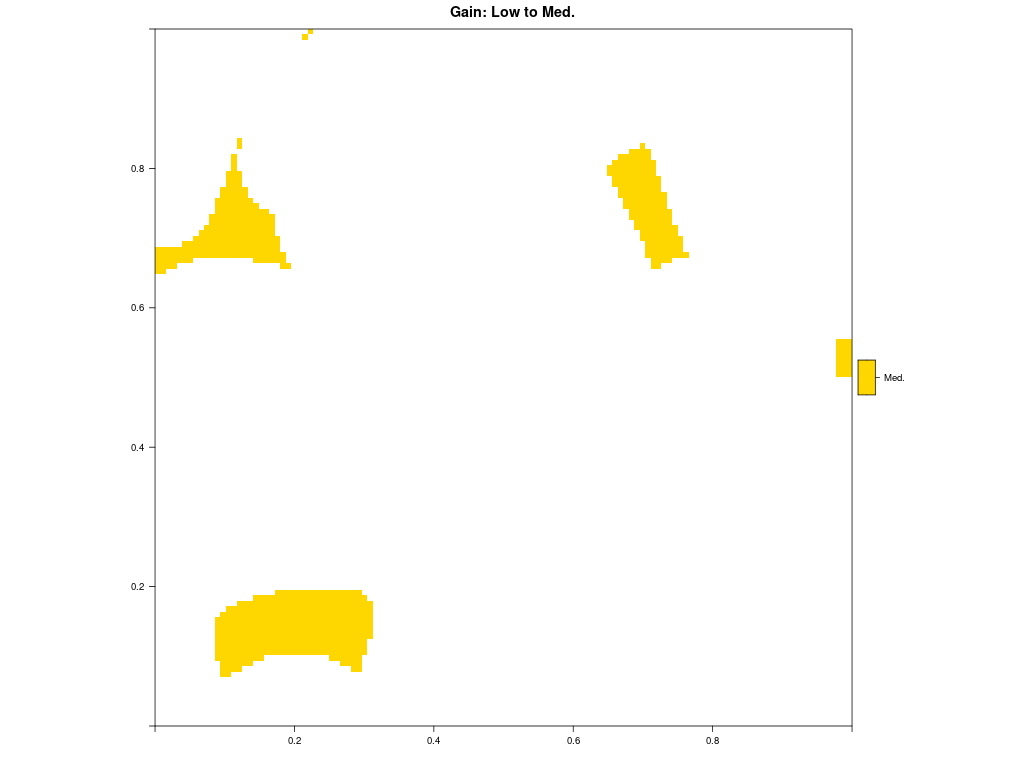

## Model performance and comparison

One of the most important tasks in fitting ENMs is ensuring that models are of the highest quality so that any decisions based on them are more likely to be appropriate and effective. This is an active area of research and the literature on choosing and interpreting model performance measures is already rich.

Although it might be tempting to treat a BRECI plot as a method of model performance evaluation…

> **A BRECI plot does not measure or represent model quality or performance.**